# Logistic regression homework

A Hameed

27/02/2022

```r
library(tidyverse)
library(janitor)
library(GGally)
library(broom)
library(pROC)
library(modelr)
```

```r
customers <- read_csv("data/orange_juice.csv") %>%
            clean_names()

head(customers)
```

```
## # A tibble: 6 × 18
##   purchase weekof_purchase store_id price_ch price_mm disc_ch disc_mm special_ch
##   <chr>              <dbl>    <dbl>    <dbl>    <dbl>   <dbl>   <dbl>      <dbl>
## 1 CH                   237        1     1.75     1.99    0        0            0
## 2 CH                   239        1     1.75     1.99    0        0.3          0
## 3 CH                   245        1     1.86     2.09    0.17     0            0
## 4 MM                   227        1     1.69     1.69    0        0            0
## 5 CH                   228        7     1.69     1.69    0        0            0
## 6 CH                   230        7     1.69     1.99    0        0            0
## # … with 10 more variables: special_mm <dbl>, loyal_ch <dbl>,
## #   sale_price_mm <dbl>, sale_price_ch <dbl>, price_diff <dbl>, store7 <chr>,
## #   pct_disc_mm <dbl>, pct_disc_ch <dbl>, list_price_diff <dbl>, store <dbl>
```

```r
glimpse(customers)
```

```
## Rows: 1,070
## Columns: 18
## $ purchase        <chr> "CH", "CH", "CH", "MM", "CH", "CH", "CH", "CH", "CH", …
## $ weekof_purchase <dbl> 237, 239, 245, 227, 228, 230, 232, 234, 235, 238, 240,…
## $ store_id        <dbl> 1, 1, 1, 1, 7, 7, 7, 7, 7, 7, 7, 7, 7, 7, 7, 7, 1, 2, …
## $ price_ch        <dbl> 1.75, 1.75, 1.86, 1.69, 1.69, 1.69, 1.69, 1.75, 1.75, …
## $ price_mm        <dbl> 1.99, 1.99, 2.09, 1.69, 1.69, 1.99, 1.99, 1.99, 1.99, …
## $ disc_ch         <dbl> 0.00, 0.00, 0.17, 0.00, 0.00, 0.00, 0.00, 0.00, 0.00, …
## $ disc_mm         <dbl> 0.00, 0.30, 0.00, 0.00, 0.00, 0.00, 0.40, 0.40, 0.40, …
## $ special_ch      <dbl> 0, 0, 0, 0, 0, 0, 1, 1, 0, 0, 0, 0, 0, 0, 0, 0, 0, 0, …
## $ special_mm      <dbl> 0, 1, 0, 0, 0, 1, 1, 0, 0, 0, 0, 0, 1, 0, 0, 0, 1, 1, …
## $ loyal_ch        <dbl> 0.500000, 0.600000, 0.680000, 0.400000, 0.956535, 0.96…
## $ sale_price_mm   <dbl> 1.99, 1.69, 2.09, 1.69, 1.69, 1.99, 1.59, 1.59, 1.59, …
## $ sale_price_ch   <dbl> 1.75, 1.75, 1.69, 1.69, 1.69, 1.69, 1.69, 1.75, 1.75, …
## $ price_diff      <dbl> 0.24, -0.06, 0.40, 0.00, 0.00, 0.30, -0.10, -0.16, -0.…
## $ store7          <chr> "No", "No", "No", "No", "Yes", "Yes", "Yes", "Yes", "Y…
## $ pct_disc_mm     <dbl> 0.000000, 0.150754, 0.000000, 0.000000, 0.000000, 0.00…
## $ pct_disc_ch     <dbl> 0.000000, 0.000000, 0.091398, 0.000000, 0.000000, 0.00…
## $ list_price_diff <dbl> 0.24, 0.24, 0.23, 0.00, 0.00, 0.30, 0.30, 0.24, 0.24, …
## $ store           <dbl> 1, 1, 1, 1, 0, 0, 0, 0, 0, 0, 0, 0, 0, 0, 0, 0, 1, 2, …
```

```r
# Let’s see if we have any missing values:

summary(customers)
```

```
##    purchase         weekof_purchase    store_id       price_ch
##  Length:1070        Min.   :227.0   Min.   :1.00   Min.   :1.690
##  Class :character   1st Qu.:240.0   1st Qu.:2.00   1st Qu.:1.790
##  Mode  :character   Median :257.0   Median :3.00   Median :1.860
##                     Mean   :254.4   Mean   :3.96   Mean   :1.867
##                     3rd Qu.:268.0   3rd Qu.:7.00   3rd Qu.:1.990
##                     Max.   :278.0   Max.   :7.00   Max.   :2.090
##     price_mm        disc_ch           disc_mm         special_ch
##  Min.   :1.690   Min.   :0.00000   Min.   :0.0000   Min.   :0.0000
##  1st Qu.:1.990   1st Qu.:0.00000   1st Qu.:0.0000   1st Qu.:0.0000
##  Median :2.090   Median :0.00000   Median :0.0000   Median :0.0000
##  Mean   :2.085   Mean   :0.05186   Mean   :0.1234   Mean   :0.1477
##  3rd Qu.:2.180   3rd Qu.:0.00000   3rd Qu.:0.2300   3rd Qu.:0.0000
##  Max.   :2.290   Max.   :0.50000   Max.   :0.8000   Max.   :1.0000
##    special_mm        loyal_ch        sale_price_mm   sale_price_ch
##  Min.   :0.0000   Min.   :0.000011   Min.   :1.190   Min.   :1.390
##  1st Qu.:0.0000   1st Qu.:0.325257   1st Qu.:1.690   1st Qu.:1.750
##  Median :0.0000   Median :0.600000   Median :2.090   Median :1.860
##  Mean   :0.1617   Mean   :0.565782   Mean   :1.962   Mean   :1.816
##  3rd Qu.:0.0000   3rd Qu.:0.850873   3rd Qu.:2.130   3rd Qu.:1.890
##  Max.   :1.0000   Max.   :0.999947   Max.   :2.290   Max.   :2.090
##    price_diff         store7           pct_disc_mm      pct_disc_ch
##  Min.   :-0.6700   Length:1070        Min.   :0.0000   Min.   :0.00000
##  1st Qu.: 0.0000   Class :character   1st Qu.:0.0000   1st Qu.:0.00000
##  Median : 0.2300   Mode  :character   Median :0.0000   Median :0.00000
##  Mean   : 0.1465                      Mean   :0.0593   Mean   :0.02731
##  3rd Qu.: 0.3200                      3rd Qu.:0.1127   3rd Qu.:0.00000
##  Max.   : 0.6400                      Max.   :0.4020   Max.   :0.25269
##  list_price_diff     store
##  Min.   :0.000   Min.   :0.000
##  1st Qu.:0.140   1st Qu.:0.000
##  Median :0.240   Median :2.000
##  Mean   :0.218   Mean   :1.631
##  3rd Qu.:0.300   3rd Qu.:3.000
##  Max.   :0.440   Max.   :4.000
```

Create a purchase mm column and turn special_ch and special mm to logical column t or f, it's more meaningful than 0 and 1 for the model.

```r
customers <- customers %>%
  mutate(purchase_mm = as.factor( if_else(purchase == "MM","yes","no")),
         store7 = as.factor(store7),
         special_mm = as.factor( if_else(special_mm == "1","t","f")),
         special_ch = as.factor( if_else(special_ch == "1","t","f"))
         )

customers
```

```
## # A tibble: 1,070 × 19
##    purchase weekof_purchase store_id price_ch price_mm disc_ch disc_mm
##    <chr>              <dbl>    <dbl>    <dbl>    <dbl>   <dbl>   <dbl>
##  1 CH                   237        1     1.75     1.99    0        0
##  2 CH                   239        1     1.75     1.99    0        0.3
##  3 CH                   245        1     1.86     2.09    0.17     0
##  4 MM                   227        1     1.69     1.69    0        0
##  5 CH                   228        7     1.69     1.69    0        0
##  6 CH                   230        7     1.69     1.99    0        0
##  7 CH                   232        7     1.69     1.99    0        0.4
##  8 CH                   234        7     1.75     1.99    0        0.4
##  9 CH                   235        7     1.75     1.99    0        0.4
## 10 CH                   238        7     1.75     1.99    0        0.4
## # … with 1,060 more rows, and 12 more variables: special_ch <fct>,
## #   special_mm <fct>, loyal_ch <dbl>, sale_price_mm <dbl>, sale_price_ch <dbl>,
## #   price_diff <dbl>, store7 <fct>, pct_disc_mm <dbl>, pct_disc_ch <dbl>,
## #   list_price_diff <dbl>, store <dbl>, purchase_mm <fct>
```

Will not select the purchase and store id and decided to leave the week of purchase column as numeric to see if give a value to the model.

```r
customers <- customers %>%
  select(-purchase, -store_id)
customers
```

```
## # A tibble: 1,070 × 17
##    weekof_purchase price_ch price_mm disc_ch disc_mm special_ch special_mm
##              <dbl>    <dbl>    <dbl>   <dbl>   <dbl> <fct>      <fct>
##  1             237     1.75     1.99    0        0   f          f
##  2             239     1.75     1.99    0        0.3 f          t
##  3             245     1.86     2.09    0.17     0   f          f
##  4             227     1.69     1.69    0        0   f          f
##  5             228     1.69     1.69    0        0   f          f
##  6             230     1.69     1.99    0        0   f          t
##  7             232     1.69     1.99    0        0.4 t          t
##  8             234     1.75     1.99    0        0.4 t          f
##  9             235     1.75     1.99    0        0.4 f          f
## 10             238     1.75     1.99    0        0.4 f          f
## # … with 1,060 more rows, and 10 more variables: loyal_ch <dbl>,
## #   sale_price_mm <dbl>, sale_price_ch <dbl>, price_diff <dbl>, store7 <fct>,
## #   pct_disc_mm <dbl>, pct_disc_ch <dbl>, list_price_diff <dbl>, store <dbl>,
## #   purchase_mm <fct>
```

Now we will see the relationships with purchase mm with other variables and We will split the variables into some sets

```r
split1 <- customers %>%
  select(weekof_purchase, price_ch, price_mm, disc_ch, disc_mm, purchase_mm)

split2 <- customers %>%
  select(special_ch, special_mm, loyal_ch, sale_price_mm, sale_price_ch,  purchase_mm)

split3 <- customers %>%
  select(price_diff, store7, pct_disc_mm, pct_disc_ch, list_price_diff, store, purchase_mm)
```

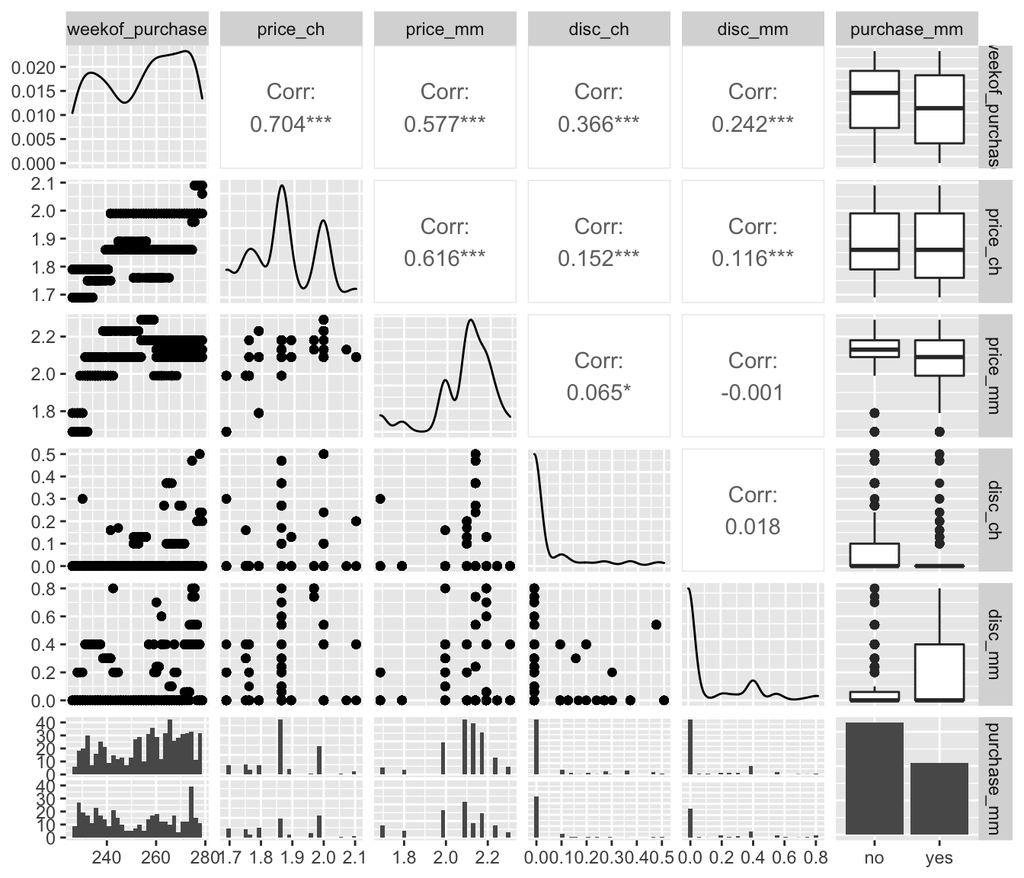

```r
split1 %>%
  ggpairs()
```

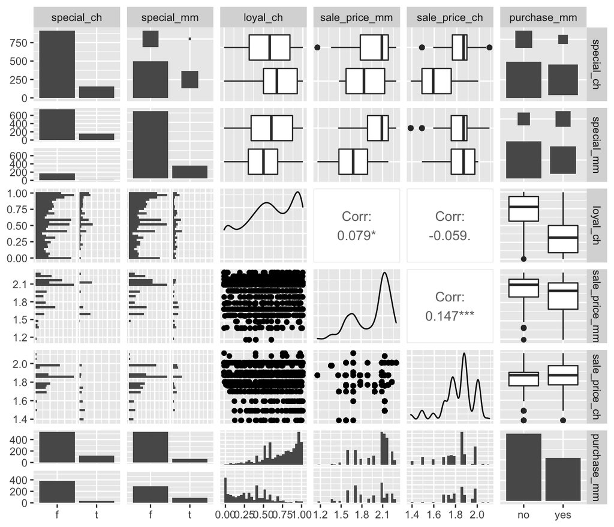

```r
split2 %>%
  ggpairs()
```

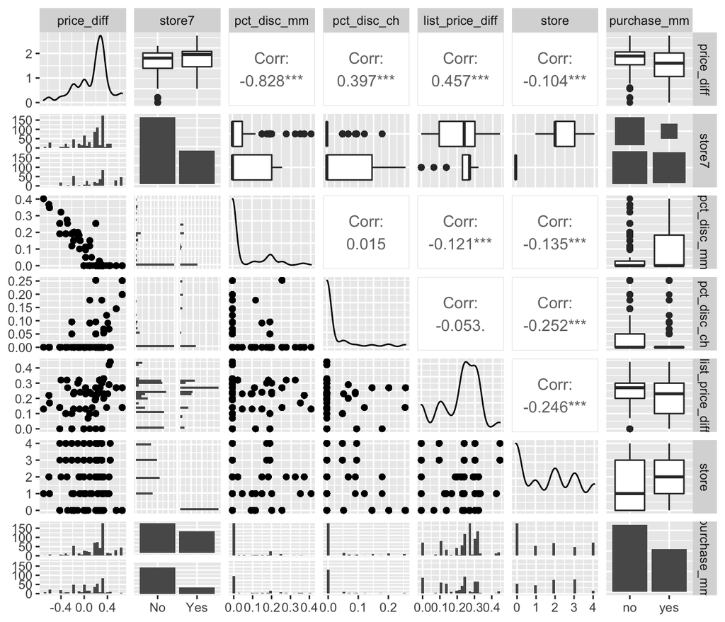

```r
split3 %>%
  ggpairs()
```

From split 1, we observe significant looking relationships between purchase_mm, price_mm, disc_mm and disc_ch and from split 2, with loyal_ch and from split 3, with pct_disc_mm, pct_disc_ch and store

```r
mod1_1pred_disc_mm <- glm(purchase_mm ~ disc_mm, data = customers, family = binomial(link = 'logit'))

mod2_1pred_loyal_ch <- glm(purchase_mm ~ loyal_ch, data = customers, family = binomial(link = 'logit'))

mod3_1pred_pct_disc_mm <- glm(purchase_mm ~ pct_disc_mm, data = customers, family = binomial(link = 'logit'))
```

```r
clean_names(tidy(mod1_1pred_disc_mm))
```

```
## # A tibble: 2 × 5
##   term        estimate std_error statistic  p_value
##   <chr>          <dbl>     <dbl>     <dbl>    <dbl>
## 1 (Intercept)   -0.650    0.0742     -8.76 1.89e-18
## 2 disc_mm        1.57     0.294       5.35 8.80e- 8
```

```r
clean_names(tidy(mod2_1pred_loyal_ch))
```

```
## # A tibble: 2 × 5
##   term        estimate std_error statistic  p_value
##   <chr>          <dbl>     <dbl>     <dbl>    <dbl>
## 1 (Intercept)     2.76     0.200      13.8 2.37e-43
## 2 loyal_ch       -6.09     0.361     -16.9 6.75e-64
```

```r
clean_names(tidy(mod3_1pred_pct_disc_mm))
```

```
## # A tibble: 2 × 5
##   term        estimate std_error statistic  p_value
##   <chr>          <dbl>     <dbl>     <dbl>    <dbl>
## 1 (Intercept)   -0.652    0.0744     -8.76 1.97e-18
## 2 pct_disc_mm    3.30     0.617       5.34 9.25e- 8
```

```r
#summary(mod3_1pred_pct_disc_mm)
```

The p-values for the 3 models are less α=0.05 so its statistically significant.

Now we will Plot ROC curves for each classifier and show the AUC values for each classifiers to see which of them is the best.

```r
     mod1 <- customers %>%
  add_predictions(mod1_1pred_disc_mm, type = "response")

 mod2 <- customers %>%
  add_predictions(mod2_1pred_loyal_ch, type = "response")

   mod3 <- customers %>%
  add_predictions(mod3_1pred_pct_disc_mm, type = "response")

roc_obj_mod1 <-  mod1 %>%
  roc(response = purchase_mm, predictor = pred)

roc_obj_mod2 <- mod2 %>%
  roc(response = purchase_mm, predictor = pred)

roc_obj_mod3 <- mod3 %>%
  roc(response = purchase_mm, predictor = pred)
```

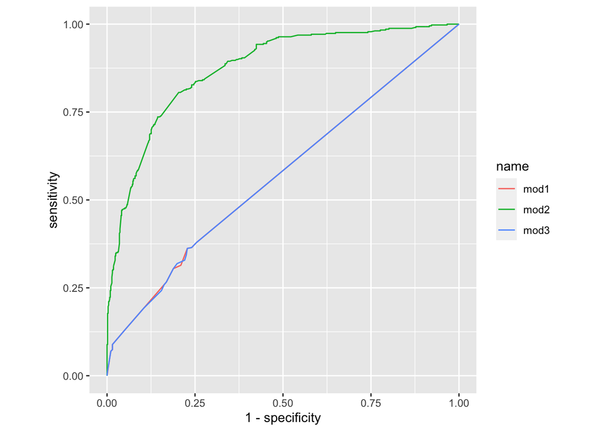

```r
roc_curve <- ggroc(
  data = list(
    mod1 = roc_obj_mod1,
    mod2 = roc_obj_mod2,
    mod3 = roc_obj_mod3
  ),
  legacy.axes = TRUE) +
  coord_fixed()

roc_curve
```

Let’s confirm this with AUC values that the model 2 ROC curves with loyal_ch is the best classifier.

```r
auc(roc_obj_mod1)
```

```
## Area under the curve: 0.5702
```

```r
auc(roc_obj_mod2)
```

```
## Area under the curve: 0.874
```

```r
auc(roc_obj_mod3)
```

```
## Area under the curve: 0.57
```

The Area under the curve of model2 is 87% which is the best of the 3 models.